# Compare Crosswalk Quality

Author

JP Walsh

Published

January 5, 2024

Read in packages for use.

```r
library(tidyverse)
library(Hmisc)
library(reactable)

options(scipen = 999)
```

Read in the several crosswalks that have been used.

```r
old_cw_pre22 <- read_csv(here::here("geographic-crosswalks", "data", "geocorr2012_PUMA_Places_2020.csv"))
new_cw_pre22 <- read_csv(here::here("geographic-crosswalks", "data", "raw", "geocorr2018_puma_place_2010.csv"))
```

## Clean crosswalks

Filter out the row containing metadata and select only needed variables.

```r
old_cw_pre22 <- old_cw_pre22 %>%
  rename_with(tolower) %>%
  filter(!str_detect(state, "State")) %>%
  select(state, puma12, place, pop20, afact, afact2)

new_cw_pre22 <- new_cw_pre22 %>%
  rename_with(tolower) %>%
  filter(!str_detect(state, "State")) %>%
  select(state, puma12, placefp14, pop10, afact, afact2)
```

Rename GeoCorr variables for working purposes. Add leading zeros to state fips, PUMAs and places to make them uniform in length.

```r
old_cw_pre22 <- old_cw_pre22 %>%
  rename(
    puma = puma12,
    statefip = state
    ) %>%
  mutate(
    statefip = sprintf("%0.2d", as.numeric(statefip)),
    puma = sprintf("%0.5d", as.numeric(puma)),
    place = sprintf("%0.5d", as.numeric(place))
  )

new_cw_pre22 <- new_cw_pre22 %>%
  rename(
    puma = puma12,
    statefip = state,
    place = placefp14
    ) %>%
  mutate(
    statefip = sprintf("%0.2d", as.numeric(statefip)),
    puma = sprintf("%0.5d", as.numeric(puma)),
    place = sprintf("%0.5d", as.numeric(place))
  )
```

Convert weight variables to be type numeric.

```r
old_cw_pre22 <- old_cw_pre22 %>%
  mutate(
    afact = as.double(afact),
    afact2 = as.double(afact2),
    pop20 = as.double(pop20)
  )

new_cw_pre22 <- new_cw_pre22 %>%
  mutate(
    afact = as.double(afact),
    afact2 = as.double(afact2),
    pop10 = as.double(pop10)
  )
```

We want to limit the crosswalk only to Places that will be used in the final mobility metric data - this will help limit the size of future data steps. Bring in the Places population file (place-populations.csv) to select only places included in the UMF data. Keep only one year of place information.

```r
places <- read_csv(here::here("geographic-crosswalks", "data", "place-populations.csv")) %>%
  filter(year == 2021) %>%
  select(-population, -year)
```

Rename the Place population variables to prep for merge.

```r
places <- places %>%
  rename(statefip = state)
```

Left join crosswalk data onto the Place population file to get rid of irrelevant Places in the crosswalk data.

```r
old_cw_pre22 <- left_join(places, old_cw_pre22, by=c("statefip","place"))
new_cw_pre22 <- left_join(places, new_cw_pre22, by=c("statefip","place"))
```

Look at summary stats on population weights between old and new.

```r
new_cw_pre22 %>%
  select(afact, afact2) %>%
  summary()
```

```
     afact            afact2
 Min.   :0.0000   Min.   :0.00000
 1st Qu.:0.0365   1st Qu.:0.01383
 Median :0.5138   Median :0.06720
 Mean   :0.4996   Mean   :0.24089
 3rd Qu.:0.9446   3rd Qu.:0.28142
 Max.   :1.0000   Max.   :1.00000
 NA's   :1        NA's   :1
```

```r
old_cw_pre22 %>%
  select(afact, afact2) %>%
  summary()
```

```
     afact            afact2
 Min.   :0.0000   Min.   :0.0000
 1st Qu.:0.0155   1st Qu.:0.0116
 Median :0.4034   Median :0.0861
 Mean   :0.4489   Mean   :0.2817
 3rd Qu.:0.9172   3rd Qu.:0.4656
 Max.   :1.0000   Max.   :1.0000
```

Compare afact distributions.

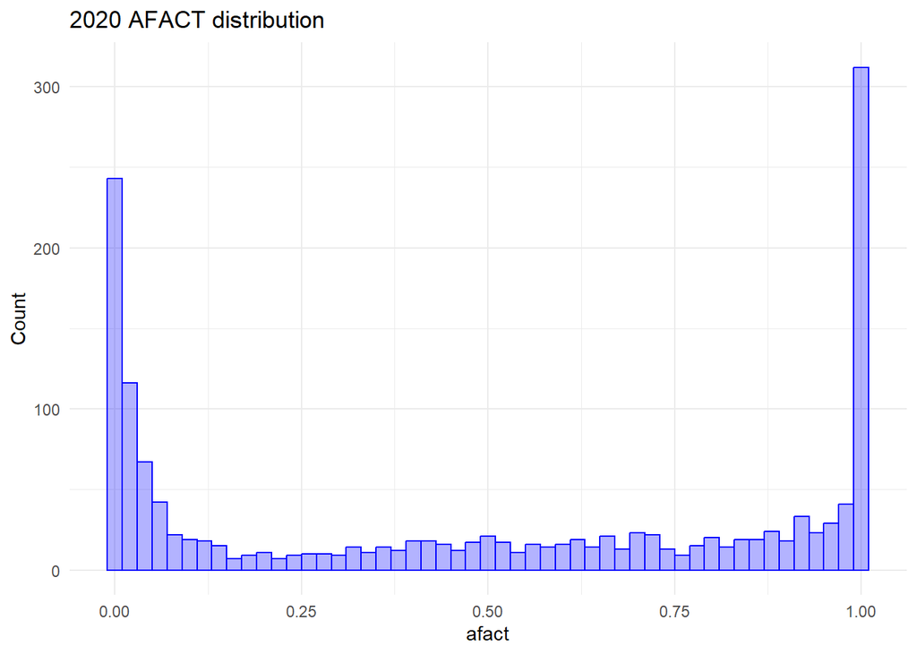

```r
new_cw_pre22 %>%
  ggplot(aes(x = afact)) +
  geom_histogram(color = "blue", fill = alpha("blue", 0.3), binwidth = 0.02) +
  theme_minimal() +
  ggtitle("2020 AFACT distribution") +
  ylab("Count")
```

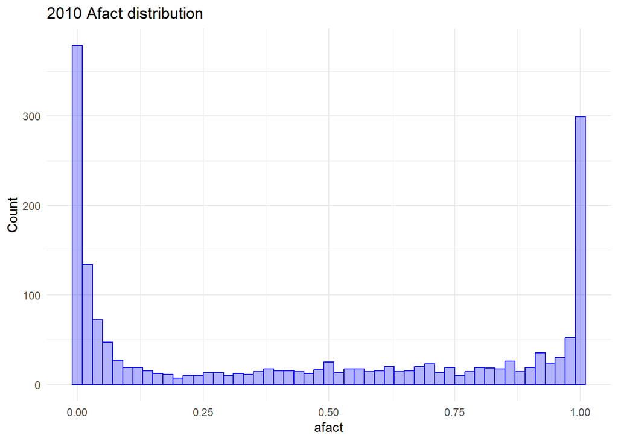

```r
old_cw_pre22 %>%
  ggplot(aes(x = afact)) +
  geom_histogram(color = "blue", fill = alpha("blue", 0.3), binwidth = 0.02) +
  theme_minimal() +
  ggtitle("2010 Afact distribution") +
  ylab("Count")
```

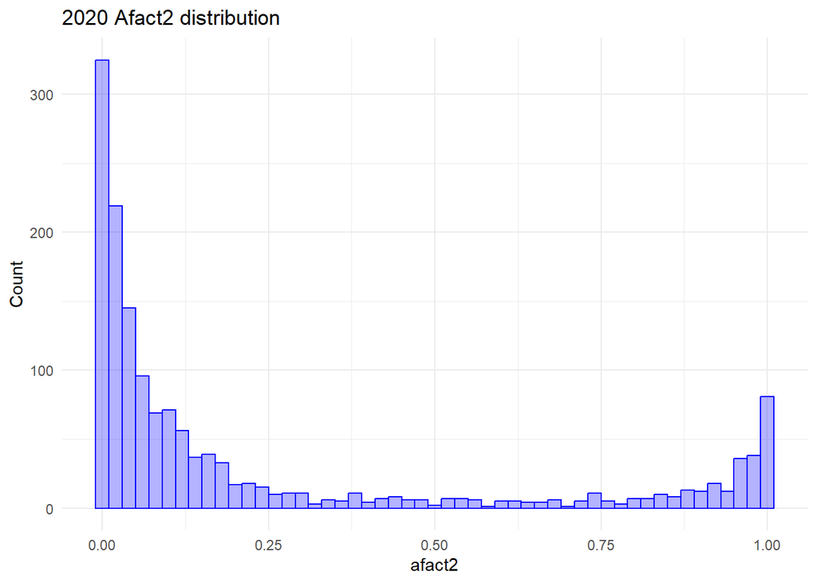

```r
new_cw_pre22 %>%
  ggplot(aes(x = afact2)) +
  geom_histogram(color = "blue", fill = alpha("blue", 0.3), binwidth = 0.02) +
  theme_minimal() +
  ggtitle("2020 Afact2 distribution") +
  ylab("Count")
```

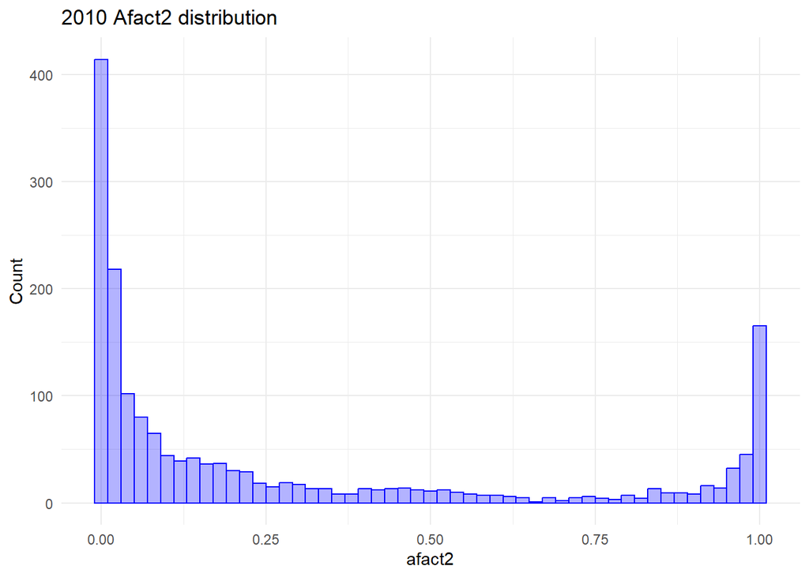

```r
old_cw_pre22 %>%
  ggplot(aes(x = afact2)) +
  geom_histogram(color = "blue", fill = alpha("blue", 0.3), binwidth = 0.02) +
  theme_minimal() +
  ggtitle("2010 Afact2 distribution") +
  ylab("Count")
```

```r
puma_place_old <- old_cw_pre22 %>%
  mutate(products = afact * afact2)

puma_place_new <- new_cw_pre22 %>%
  mutate(products = afact * afact2)
```

Calculate the total place population by summing the GeoCorr pop10 and pop20 variables. These pop variables count the population in the PUMA that overlap with the place - note that GeoCorr presents these numbers so that it already accounts for afact (see What is a Correlation List? on the [GeoCorr website](https://mcdc.missouri.edu/applications/docs/geocorr-help.html#weightVar)).

```r
puma_place_old <- puma_place_old %>%
  group_by(statefip, place) %>%
  mutate(sum_products = sum(products),
         place_pop = sum(pop20)) %>%
  ungroup()

puma_place_new <- puma_place_new %>%
  group_by(statefip, place) %>%
  mutate(sum_products = sum(products),
         place_pop = sum(pop10)) %>%
  ungroup()
```

```r
puma_place_old %>%
  select(sum_products, place_pop) %>%
  summary()
```

```
  sum_products      place_pop
 Min.   :0.2129   Min.   :  74793
 1st Qu.:0.6429   1st Qu.: 110629
 Median :0.7924   Median : 196100
 Mean   :0.7596   Mean   : 770403
 3rd Qu.:0.9204   3rd Qu.: 577222
 Max.   :1.0000   Max.   :8804190
```

```r
puma_place_new  %>%
  select(sum_products, place_pop) %>%
  summary()
```

```
  sum_products      place_pop
 Min.   :0.0193   Min.   :  45704
 1st Qu.:0.3590   1st Qu.: 100001
 Median :0.5421   Median : 190283
 Mean   :0.5531   Mean   : 736514
 3rd Qu.:0.7580   3rd Qu.: 583785
 Max.   :1.0000   Max.   :8175032
 NA's   :1        NA's   :1
```